| title: “Hierarchical beta binomial” |
| --- |
| author: “Steve Simon” |
| date: “Saturday, May 28, 2016” |
| output: html_document |

Assume that you have two “clusters”. The first is your prior data with 4/16 successes/failures and the second is your observed data with 18/42 successes/failures.

Now consider the same prior, but your observed data is 54/6 successes/failures.

Here is the simple beta-binomial model. The posterior mean of pi is a weighted average of the prior mean (4/20 or 20%) and the data mean (18/60 or 30%; 54/60 or 90%).

```r
library("rjags")
fnm <- "jags_beta_binomial.txt"
mon <- c("pi")

out <- list(description="jags output")

dat <- list(a=4, b=16, x=18, n=60)
mod <- jags.model(fnm, data=dat, quiet=TRUE)
out$bb1 <-
  coda.samples(mod, variable.names=mon, n.iter=1000, by=1000, progress.bar=NULL)
summary(out$bb1)
```

```
##
## Iterations = 1:1000
## Thinning interval = 1
## Number of chains = 1
## Sample size per chain = 1000
##
## 1. Empirical mean and standard deviation for each variable,
##    plus standard error of the mean:
##
##           Mean             SD       Naive SE Time-series SE
##       0.278476       0.049850       0.001576       0.001576
##
## 2. Quantiles for each variable:
##
##   2.5%    25%    50%    75%  97.5%
## 0.1869 0.2435 0.2760 0.3116 0.3803
```

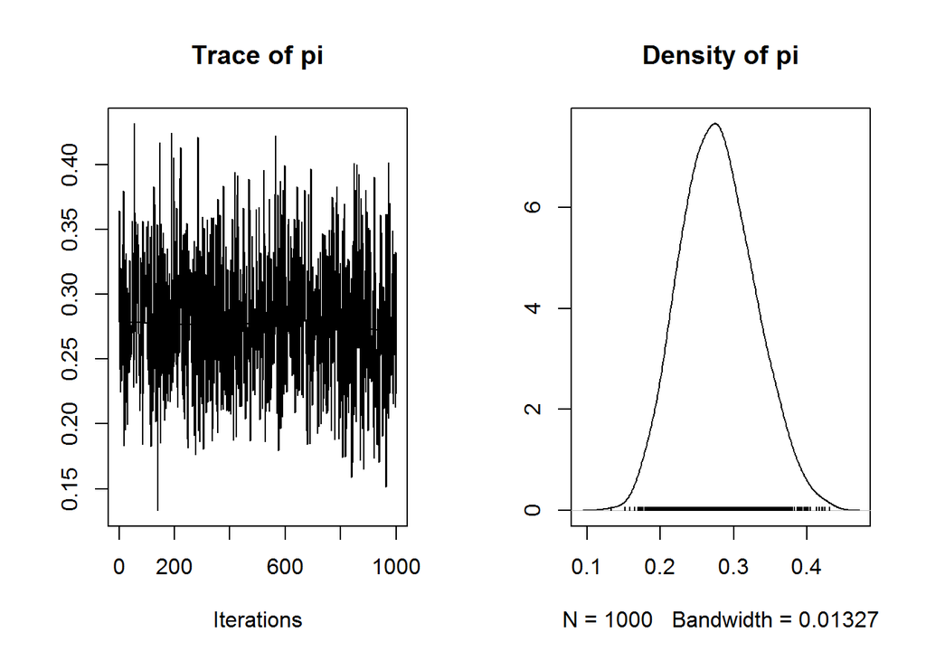

```r
plot(out$bb1)
```

```r
dat <- list(a=4, b=16, x=54, n=60)
mod <- jags.model(fnm, data=dat, quiet=TRUE)
out$bb2 <-
  coda.samples(mod, variable.names=mon, n.iter=1000, by=1000, progress.bar=NULL)
summary(out$bb2)
```

```
##
## Iterations = 1:1000
## Thinning interval = 1
## Number of chains = 1
## Sample size per chain = 1000
##
## 1. Empirical mean and standard deviation for each variable,
##    plus standard error of the mean:
##
##           Mean             SD       Naive SE Time-series SE
##       0.726138       0.049472       0.001564       0.001564
##
## 2. Quantiles for each variable:
##
##   2.5%    25%    50%    75%  97.5%
## 0.6231 0.6911 0.7281 0.7614 0.8177
```

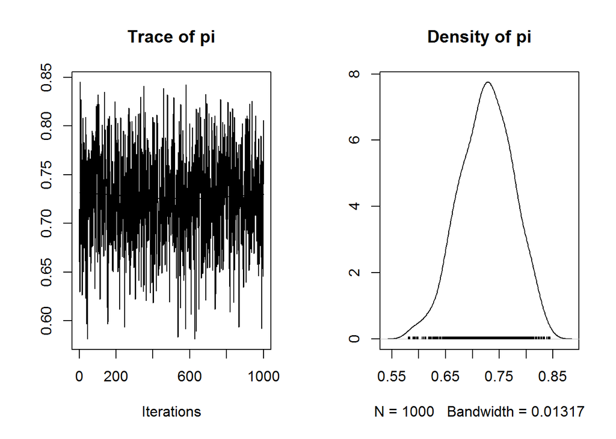

```r
plot(out$bb2)
```

You can use a hierarchical model to downweight the prior mean when the data disagrees strongly with the prior. Here’s a simple approach, though it does not work so well.

Start by assuming that both clusters (the prior and the data) are drawn from a distribution that is beta(alpha,beta) and alpha and beta are hyperpriors distributed exponentially.

```
##
## Iterations = 10001:20000
## Thinning interval = 1
## Number of chains = 1
## Sample size per chain = 10000
##
## 1. Empirical mean and standard deviation for each variable,
##    plus standard error of the mean:
##
##            Mean      SD  Naive SE Time-series SE
## hyper_a  0.9856 0.63241 0.0063241      0.0126855
## hyper_b  1.8042 1.21417 0.0121417      0.0260628
## hyper_n  2.7898 1.59293 0.0159293      0.0376680
## hyper_pi 0.3731 0.15733 0.0015733      0.0018044
## pi0      0.2185 0.08605 0.0008605      0.0009060
## pi1      0.3031 0.05753 0.0005753      0.0005753
##
## 2. Quantiles for each variable:
##
##             2.5%    25%    50%    75%  97.5%
## hyper_a  0.17133 0.5206 0.8496 1.3021 2.5914
## hyper_b  0.27591 0.9182 1.5284 2.3995 4.7862
## hyper_n  0.64071 1.6241 2.4588 3.6193 6.6815
## hyper_pi 0.10980 0.2565 0.3592 0.4747 0.7151
## pi0      0.07702 0.1543 0.2108 0.2733 0.4068
## pi1      0.19634 0.2631 0.3011 0.3412 0.4202
```

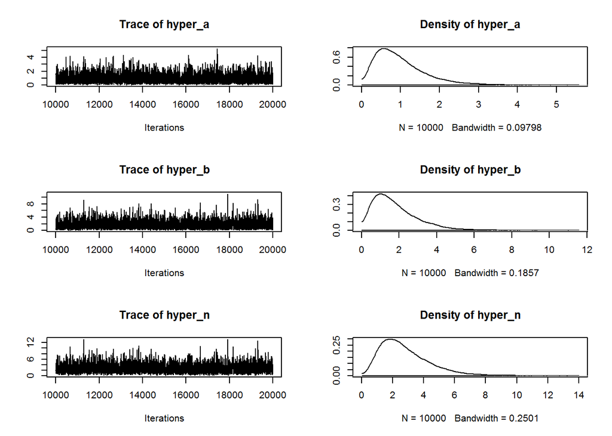

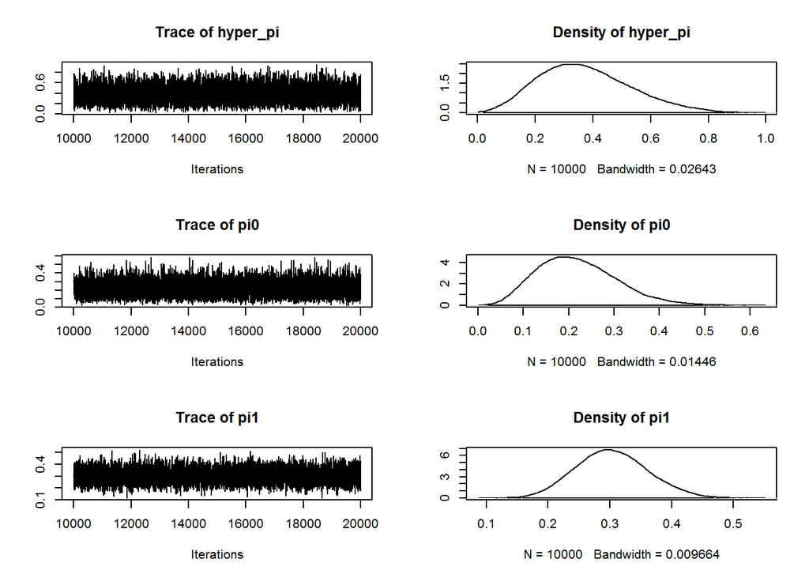

```r
run_bayes <- function(x0, n0, x, n, model_name, output_name) {
  fnm <- paste("jags", model_name, "hyper.txt", sep="_")
  dat <- list(x0=x0, n0=n0, x=x, n=n)
  mon <- c("pi0", "pi1", "hyper_a", "hyper_b", "hyper_n", "hyper_pi")
  mod <- jags.model(fnm, data=dat, quiet=TRUE, n.adapt=10000)
  out[[output_name]] <<-
    coda.samples(mod, variable.names=mon, n.iter=10000, progress.bar=NULL)
  print(summary(out[[output_name]]))
  plot(out[[output_name]])
}

run_bayes(4, 20, 18, 60, "gamma_gamma", "gg1")
```

```r
run_bayes(4, 20, 54, 60, "gamma_gamma", "gg2")
```

```
##
## Iterations = 10001:20000
## Thinning interval = 1
## Number of chains = 1
## Sample size per chain = 10000
##
## 1. Empirical mean and standard deviation for each variable,
##    plus standard error of the mean:
##
##            Mean      SD  Naive SE Time-series SE
## hyper_a  1.0685 0.71895 0.0071895      0.0140545
## hyper_b  0.8556 0.56620 0.0056620      0.0115820
## hyper_n  1.9241 1.07261 0.0107261      0.0230664
## hyper_pi 0.5455 0.17194 0.0017194      0.0021486
## pi0      0.2312 0.09158 0.0009158      0.0010603
## pi1      0.8898 0.04033 0.0004033      0.0004276
##
## 2. Quantiles for each variable:
##
##            2.5%    25%    50%    75%  97.5%
## hyper_a  0.1712 0.5389 0.9113 1.4073 2.9185
## hyper_b  0.1430 0.4478 0.7350 1.1225 2.2942
## hyper_n  0.4684 1.1443 1.7134 2.4667 4.6321
## hyper_pi 0.2035 0.4236 0.5510 0.6722 0.8539
## pi0      0.0779 0.1629 0.2238 0.2895 0.4311
## pi1      0.7997 0.8660 0.8941 0.9183 0.9555
```

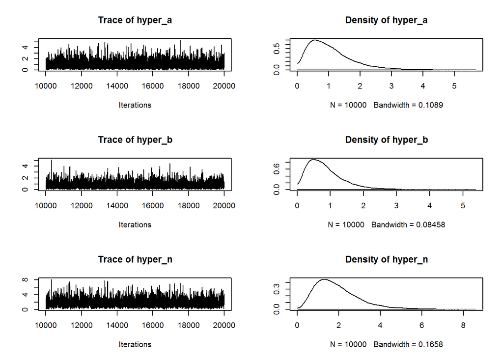

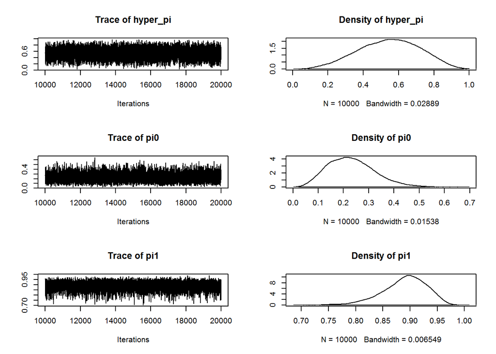

Try a uniform distribution instead.

```r
run_bayes(4, 20, 18, 60, "uniform_uniform", "uu1")
```

```
##
## Iterations = 10001:20000
## Thinning interval = 1
## Number of chains = 1
## Sample size per chain = 10000
##
## 1. Empirical mean and standard deviation for each variable,
##    plus standard error of the mean:
##
##              Mean        SD  Naive SE Time-series SE
## hyper_a  246.0079 121.44360 1.2144360      18.733811
## hyper_b  620.8632 250.62695 2.5062695      32.225756
## hyper_n  866.8711 356.42998 3.5642998      54.504384
## hyper_pi   0.2800   0.05322 0.0005322       0.003593
## pi0        0.2776   0.05484 0.0005484       0.003546
## pi1        0.2818   0.05165 0.0005165       0.003522
##
## 2. Quantiles for each variable:
##
##              2.5%      25%      50%       75%     97.5%
## hyper_a   47.9316 151.8866 234.4408  332.1659  517.9905
## hyper_b  130.2924 423.0502 649.9286  839.5665  982.7474
## hyper_n  180.3709 585.1236 903.4394 1161.9085 1439.1496
## hyper_pi   0.1842   0.2402   0.2790    0.3186    0.3846
## pi0        0.1767   0.2368   0.2774    0.3167    0.3848
## pi1        0.1883   0.2434   0.2806    0.3186    0.3822
```

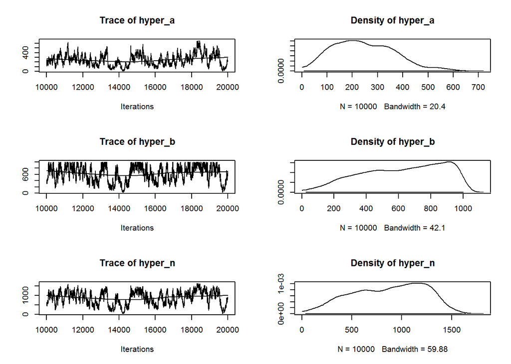

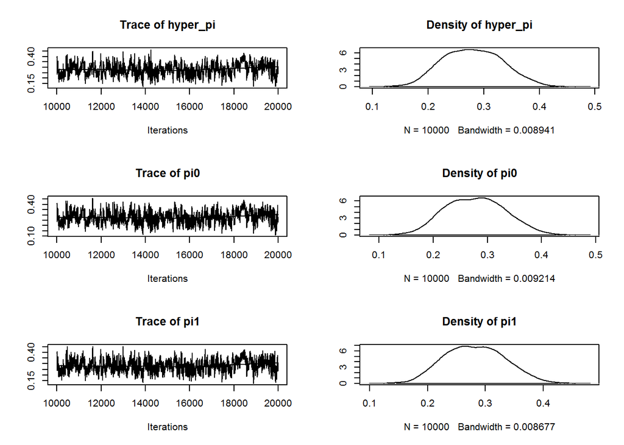

```r
run_bayes(4, 20, 54, 60, "uniform_uniform", "uu2")
```

```
##
## Iterations = 10001:20000
## Thinning interval = 1
## Number of chains = 1
## Sample size per chain = 10000
##
## 1. Empirical mean and standard deviation for each variable,
##    plus standard error of the mean:
##
##            Mean       SD  Naive SE Time-series SE
## hyper_a  5.4853  7.92011 0.0792011       0.807099
## hyper_b  3.2022  3.42089 0.0342089       0.285883
## hyper_n  8.6875 10.96494 0.1096494       1.053595
## hyper_pi 0.5952  0.14127 0.0014127       0.001858
## pi0      0.3056  0.11674 0.0011674       0.004533
## pi1      0.8685  0.04734 0.0004734       0.001126
##
## 2. Quantiles for each variable:
##
##            2.5%    25%    50%    75%   97.5%
## hyper_a  0.5098 1.8167 3.2842 6.1827 23.1855
## hyper_b  0.3820 1.2947 2.1901 3.8107 12.5959
## hyper_n  1.1700 3.2926 5.6073 9.7465 34.6771
## hyper_pi 0.2845 0.5055 0.6072 0.6976  0.8404
## pi0      0.1111 0.2213 0.2954 0.3784  0.5619
## pi1      0.7626 0.8386 0.8737 0.9033  0.9454
```

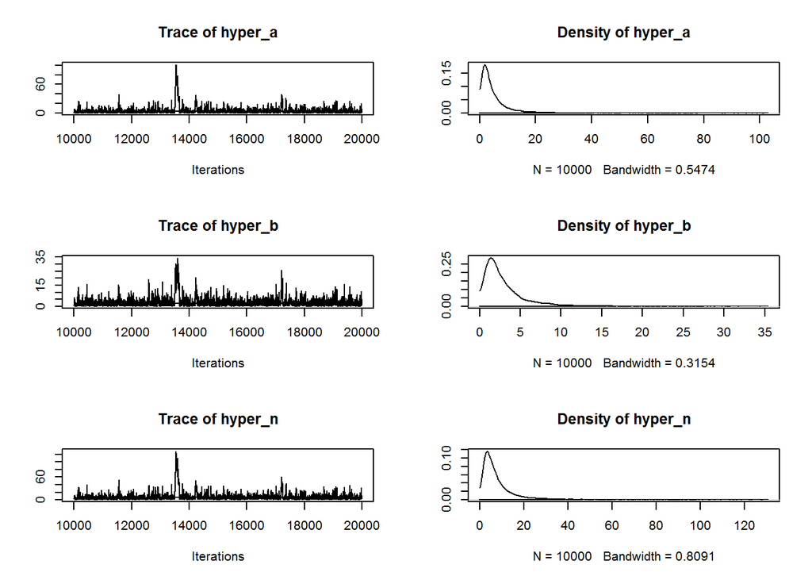

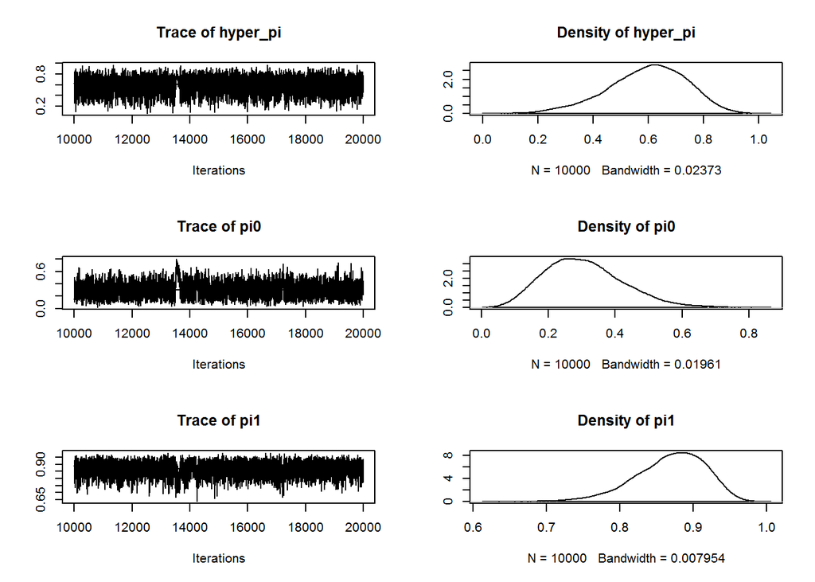

The problem with this model, according to some sources is that the two hyper parameters are correlated so highly as to make the Gibbs sampler inefficient.

You can avoid much of this correlation by re-parameterizing.

```r
run_bayes(4, 20, 18, 60, "beta_pareto", "bp1")
```

```
##
## Iterations = 10001:20000
## Thinning interval = 1
## Number of chains = 1
## Sample size per chain = 10000
##
## 1. Empirical mean and standard deviation for each variable,
##    plus standard error of the mean:
##
##            Mean      SD  Naive SE Time-series SE
## hyper_a  1.3794 1.73105 0.0173105      0.0951368
## hyper_b  2.9152 4.41747 0.0441747      0.2618844
## hyper_n  4.2946 5.98423 0.0598423      0.3577975
## hyper_pi 0.3674 0.15750 0.0015750      0.0028595
## pi0      0.2190 0.08698 0.0008698      0.0009676
## pi1      0.3022 0.05808 0.0005808      0.0005972
##
## 2. Quantiles for each variable:
##
##            2.5%    25%    50%    75%   97.5%
## hyper_a  0.1936 0.5193 0.8300 1.4682  6.7469
## hyper_b  0.3691 0.8412 1.3826 2.9367 17.0904
## hyper_n  1.0316 1.4117 2.1806 4.3598 23.8579
## hyper_pi 0.1098 0.2516 0.3493 0.4664  0.7207
## pi0      0.0747 0.1548 0.2108 0.2728  0.4098
## pi1      0.1945 0.2616 0.3003 0.3401  0.4213
```

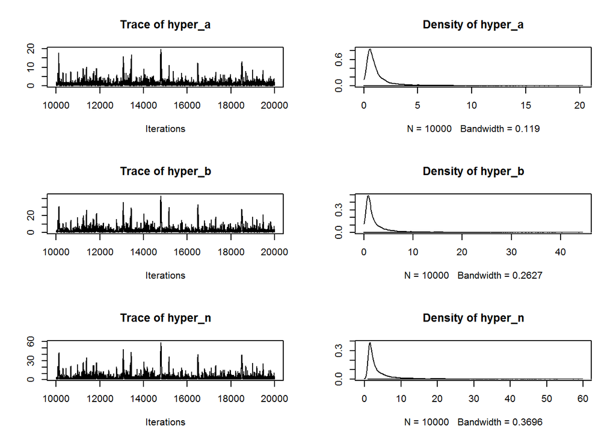

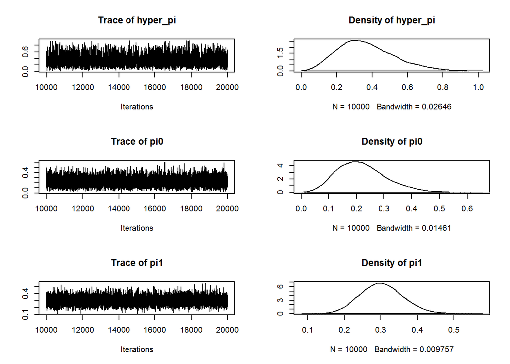

```r
run_bayes(4, 20, 54, 60, "beta_pareto", "bp2")
```

```
##
## Iterations = 10001:20000
## Thinning interval = 1
## Number of chains = 1
## Sample size per chain = 10000
##
## 1. Empirical mean and standard deviation for each variable,
##    plus standard error of the mean:
##
##            Mean      SD  Naive SE Time-series SE
## hyper_a  0.9737 0.71622 0.0071622       0.027828
## hyper_b  0.8039 0.52909 0.0052909       0.015403
## hyper_n  1.7777 1.05509 0.0105509       0.042483
## hyper_pi 0.5416 0.17322 0.0017322       0.002282
## pi0      0.2283 0.08948 0.0008948       0.001017
## pi1      0.8896 0.04037 0.0004037       0.000449
##
## 2. Quantiles for each variable:
##
##             2.5%    25%    50%    75%  97.5%
## hyper_a  0.25548 0.5835 0.8168 1.1576 2.6395
## hyper_b  0.19451 0.4791 0.6866 0.9820 2.0814
## hyper_n  1.01558 1.1849 1.4625 1.9894 4.3475
## hyper_pi 0.19624 0.4204 0.5469 0.6697 0.8569
## pi0      0.07905 0.1626 0.2200 0.2857 0.4221
## pi1      0.80113 0.8648 0.8941 0.9192 0.9559
```

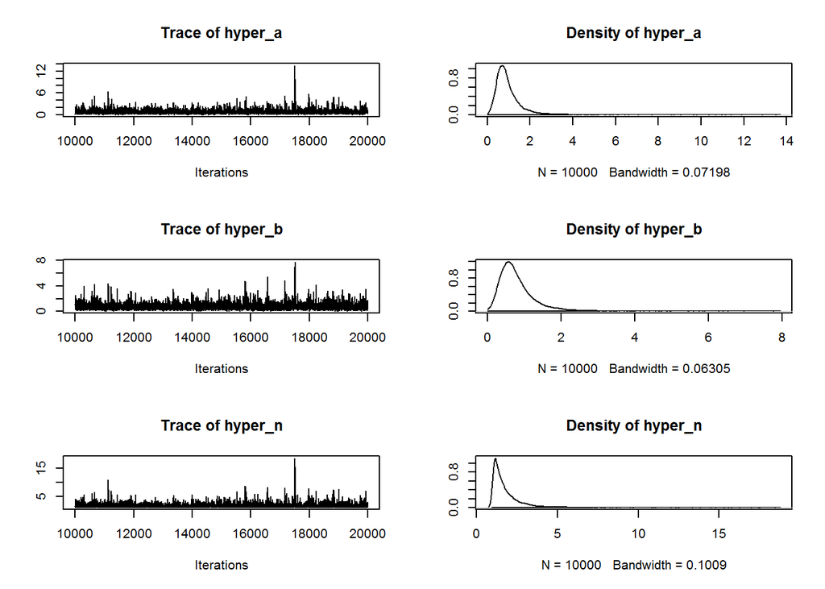

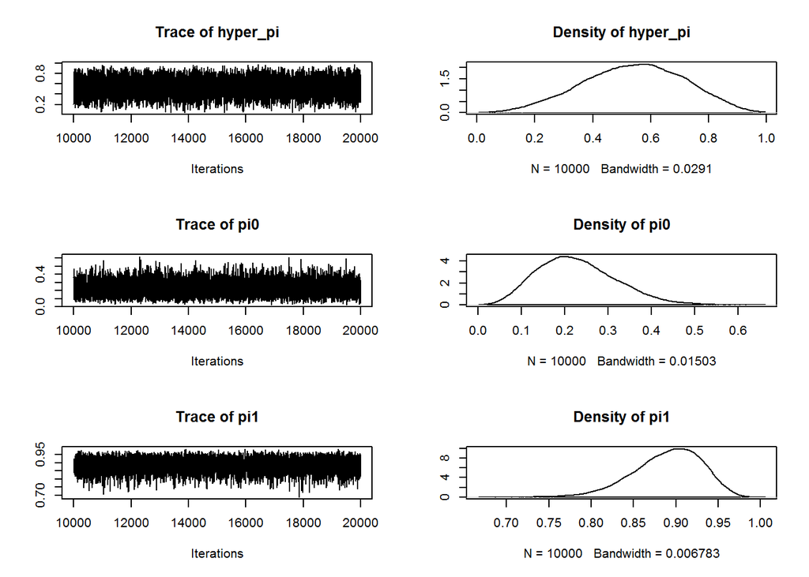

```r
save.image("run_hierarchical_models.RData")
```